# 00-Manual_linux

## Practicas Micropython - Jupyterlab

**Ejecutando python en una placa/dispositivo IOT.**

[figure not shown]

## Usaremos Jupyterlab Desktop

- Se puede hacer portable
- No requiere permisos de administrador
- Entorno python portable en espacio de usuario

https://github.com/jupyterlab/jupyterlab-desktop/releases

1. Descomprimimos el paquete.  
   `dpkg --extract JupyterLab-Setup-Debian.deb JupyterLab`
2. Arrancamos JupyterLab (es una app electron).

[figure not shown]

3. Instalamos el entorno.

[figure not shown]

- Es posible que tarde un rato.

[figure not shown]

[figure not shown]

5. lo ejecutamos de nuevo.(asi se instalara el kernel para Micropython)

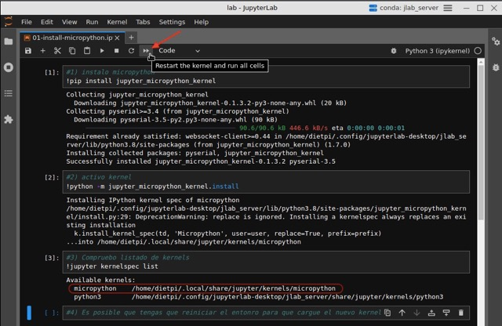

   En la lista de kernels disponibles ya deberia aparecer micropython

   **Nota:** Los comandos ejecutados son:

```
pip install jupyter_micropython_kernel
python -m jupyter_micropython_kernel.install
jupyter kernelspec list
```

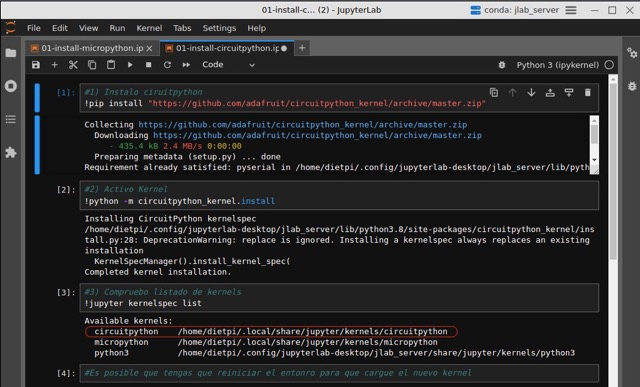

   En la lista de kernels disponibles ya deberia aparecer circuitpython

   **Nota:** Los comandos ejecutados son:

```
pip install "https://github.com/adafruit/circuitpython_kernel/archive/master.zip"
python -m circuitpython_kernel.install
jupyter kernelspec list
```

7. En el lanzador ya deberiamos ver los kernels.

[figure not shown]

- Si abrimos una consola de Circuitpython y ejecutamos help()  
  Es posible que no detecte la placa. (por defecto solo detecta unas pocas placas)

[figure not shown]

- Esto se soluciona facilmente editando board.py  
  y poniendo el VID de nuestra placa como se ve en la imagen.

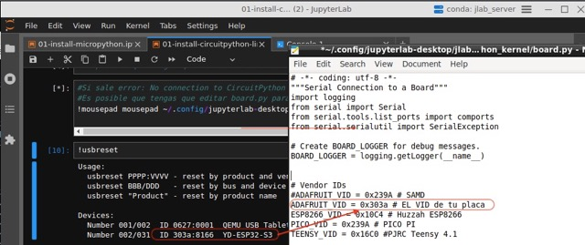

### Ya tenemos acceso ejecutar codigo en la placa.

[figure not shown]